# Interactome analysis for Joshi, Watanabi et al. 2019

```r
library(assertthat)
library(Seurat)
library(readxl)
library(dplyr)
library(ggplot2)
library(simpleCache)
```

```r
simpleCache::setCacheDir(".cache")
```

## Load data

Seurat v3 objects for — whole lung — macrophages subset — alveolar type 2 cells subset

```r
load("data/lung_SeuratV3.Robj")
load("data/Macrophages2.Robj")
load("data/AT2_clean.Robj")
```

Read in tables of ligands and receptors in pairs. Data from Skelly et. al 2018 (https://www.ncbi.nlm.nih.gov/pubmed/29346760)

```r
pairs <- read_xlsx('mmc4.xlsx', skip = 4, col_names = T)
```

```
-
/
```

```r
pairs <- pairs[pairs$ligand_symbol %in% rownames(lung), ]
```

## Preprocess data

Remove doublet clusters and rename the rest of the clusters to human-readable cell types. Split the combined object by sample: TiO2 and Asbestos mice

```r
lung <- subset(lung, idents = c(30,34,37), invert = T)
lung <- RenameIdents(
    lung,
    '0'='Classical_monocytes',
    '1'='AT2',
    '2'='B_cells',
    '3'='T_cells',
    '4'='AT2',
    '5'='Non-classical_monocytes',
    '6'='TRAM',
    '7'='Neutrophils',
    '8'='TRAM',
    '9'='IM',
    '10'='NK_cells',
    '11'='DC2',
    '12'='AT2',
    '13'='Endo_1',
    '14'='Club_cells',
    '15'='DC1',
    '16'='Endo_2',
    '17'='T_cells',
    '18'='Neutrophils',
    '19'='MoAM',
    '20'='Ciliated_cells',
    '21'='AT2_Retnla',
    '22'='Neutrophils',
    '23'='ILC',
    '24'='TRAM',
    '25'='Proliferating_TRAM',
    '26'='pDC',
    '27'='Tregs',
    '28'='Fibroblasts',
    '29'="Ccr7_DC",
    '31'='Mesothelium',
    '32'='AT1',
    '33'='Proliferating_DC',
    '35'='Smooth_muscle_cells',
    '36'='Lymphatics',
    '38'='Mast_cells'
)
lung_ti <- subset(lung, cells = WhichCells(lung, expression = orig.ident == 'SC14'))
lung_as <- subset(lung, cells = WhichCells(lung, expression = orig.ident == 'SC15'))
```

## Utility functions

```r
# Function to determine expression level of gene in cluster
expressed <- function(x, cell_pops) {
  assert_that(length(x) == length(cell_pops))
  tapply(x, cell_pops, function(y) { mean(y > 0) })
}
# Utility function to get raw RNA counts from Seurat 3 object
get_gene_counts <- function(obj, genes) {
    genes <- genes[genes %in% rownames(obj)]
    return(GetAssayData(obj, slot = "counts")[genes, ])
}
# Compute table of interactions for given ligand and receptor cluster expression values
get_all_interactions <- function(ligands, receptors, pairs) {
    all_ints <- expand.grid(rownames(ligands), rownames(ligands), 1:nrow(pairs))
    levels <- t(mapply(function(x, y, z) {
        ligand <- pairs$ligand_symbol[z]
        receptor <- pairs$receptor_symbol[z]
        l <- ifelse(ligand %in% colnames(ligands), ligands[x, ligand], 0)
        r <- ifelse(receptor %in% colnames(receptors), receptors[y, receptor], 0)
        return(c(l, r))
    }, all_ints$Var1, all_ints$Var2, all_ints$Var3))
    ints_expression <- as.data.frame(levels)
    ints_expression$int_exp <- apply(levels, 1, min)
    all_ints <- cbind(all_ints, ints_expression)
    colnames(all_ints) <- c("ligand_cl", "receptor_cl", "lr_id", "ligand_exp", "receptor_exp", "int_exp")
    all_ints <- all_ints[all_ints$int_exp > 0,]
    all_ints$id <- paste0(all_ints$ligand_cl, "->", all_ints$receptor_cl, "/", all_ints$lr_id)
    return(all_ints)
}
# Plot heatmap of number of interactions between different clusters
# Sorts clusters automatically by descending total count
heatmap_interactions <- function(data_name,
                                 int_table,
                                 threshold = 0.1,
                                 show_labels = F,
                                 limit = NULL,
                                 breaks = NULL)
{
    int_table$ligand_cl <- droplevels(int_table$ligand_cl)
    int_table$receptor_cl <- droplevels(int_table$receptor_cl)
    int_table <- int_table[int_table$int_exp > threshold, ]
    int_table_cnt <- int_table %>% group_by(ligand_cl, receptor_cl) %>% summarize(Count=n())
    l_order <- order((int_table %>% group_by(ligand_cl) %>% summarize(Count=n()))$Count)
    r_order <- order((int_table %>% group_by(receptor_cl) %>% summarize(Count=n()))$Count)
    int_table_cnt$ligand_cl <- factor(
        int_table_cnt$ligand_cl,
        levels = levels(int_table_cnt$ligand_cl)[l_order]
    )
    int_table_cnt$receptor_cl <- factor(
        int_table_cnt$receptor_cl,
        levels = rev(levels(int_table_cnt$receptor_cl)[r_order])
    )
    levels(int_table_cnt$ligand_cl) <- gsub('_', ' ', levels(int_table_cnt$ligand_cl), fixed = TRUE)
    levels(int_table_cnt$receptor_cl) <- gsub('_', ' ', levels(int_table_cnt$receptor_cl), fixed = TRUE)
    if (is.null(limit)) {
        limit <- c(0, max(int_table_cnt$Count))
    }
    if (is.null(breaks)) {
        breaks  <- waiver()
    }
    plt <- (ggplot(data=int_table_cnt, aes(y=ligand_cl, x=receptor_cl, fill=Count))
            + geom_tile()
            + scale_fill_gradient(
                low="#dddddd",
                high="#003366",
                limit=limit,
                name="Number of\nInteractions",
                breaks=breaks
            )
            + theme_minimal()
            + theme(
                axis.text.x = element_text(angle = 90, hjust=1, vjust=0.5, size=11),
                axis.text.y = element_text(size=11),
                axis.title = element_text(size=8, color="gray40")
            )
            + xlab("Receptor")
            + ylab("Ligand")
            + ggtitle(paste0(
                "All possible interactions in ",
                data_name,
                "\nexpression threshold=",
                threshold * 100,
                "%"
            ))
            + coord_fixed())
    if (show_labels) {
        plt <- plt + geom_text(aes(label=Count), color = "white")
    }
    return(plt)
}
# Given two tables from `get_all_interactions` call computes the difference
# and plots a heatmap of interaction difference
heatmap_difference <- function(data_name_old, data_name_new, ints_old, ints_new, threshold, show_value = F) {
    ints_old <- ints_old[ints_old$int_exp > threshold, ]
    ints_new <- ints_new[ints_new$int_exp > threshold, ]
    new_specific <- ints_new[!(ints_new$id %in% ints_old$id), ]
    heatmap <- heatmap_interactions("", new_specific, threshold)

    if (show_value) {
        heatmap <- heatmap + geom_text(aes(label=Count), color = "white")
    }

    return(
        heatmap
            + ggtitle(paste0(
                "All possible interactions in ",
                data_name_new,
                "\nwhich are absent in ",
                data_name_old,
                "\nexpression threshold=",
                threshold * 100,
                "%"
            ))
    )
}
# Renames Seurat v3 clusters by adding `orig.ident` value
# to each cluster
split_clusters <- function(obj) {
    data <- FetchData(obj, c("orig.ident", "ident"))

    uniq_by <- unique(obj[["orig.ident"]])$orig.ident
    clusters <- levels(obj)
    for (by_value in uniq_by) {
        for (cluster in clusters) {
            Idents(obj, cells = rownames(
                data[data$orig.ident == by_value & data$ident == cluster, ]
            )) <- paste0(cluster, "_", by_value)
        }
    }
    return(obj)
}
# Runs `FindMarkers` for each cluster in Seurat v3 object,
# finding DE genes between two samples within each cluster
compute_split_de_genes <- function(orig_obj, split_obj, genes, by = "orig.ident", threshold = 0.1) {
    uniq_by <- unique(orig_obj[[by]])[[by]]
    assert_that(length(uniq_by) == 2)
    clusters <- levels(orig_obj)
    res <- data.frame()
    for (cluster in clusters) {
        if (length(WhichCells(
            split_obj,
            idents = c(paste0(cluster, "_", uniq_by[1]))
        )) < 3 || length(WhichCells(
            split_obj,
            idents = c(paste0(cluster, "_", uniq_by[2]))
        )) < 3) {
            next
        }
        de_genes <- FindMarkers(
            split_obj,
            test = "negbinom",
            ident.1 = paste0(cluster, "_", uniq_by[1]),
            ident.2 = paste0(cluster, "_", uniq_by[2]),
            min.pct = threshold,
            genes.use = genes,
            verbose = FALSE
        )
        de_genes <- de_genes[de_genes$p_val_adj < 0.05, ]
        if (nrow(de_genes) > 0) {
            de_genes$cluster <- cluster
        }
        res <- rbind(res, de_genes)
    }
    return(res)
}
# Subsets from `full_ints` interaction table to the interactions
# involving any of the genes in `de_genes` differentially expressed table
get_de_interactions <- function(de_genes, full_ints, pairs) {
    l_c <- de_genes[rownames(de_genes) %in% pairs$ligand_symbol, c(6), drop = FALSE]
    r_c <- de_genes[rownames(de_genes) %in% pairs$receptor_symbol, c(6), drop = FALSE]
    l_idx <- paste0(pairs$ligand_symbol[full_ints$lr_id], "/", full_ints$ligand_cl) %in% paste0(rownames(l_c), "/", l_c$cluster)
    r_idx <- paste0(pairs$receptor_symbol[full_ints$lr_id], "/", full_ints$receptor_cl) %in% paste0(rownames(r_c), "/", r_c$cluster)
    return(full_ints[l_idx | r_idx, ])
}
# Helper function to save plots as pdf
figure <- function(path, f) {
  pdf(path, width = 9, height = 7)
  f()
  dev.off()
}
```

## L/R analysis

First we compute expression values for each cluster for each ligand and each receptor gene. Separately for TiO2 and Asbestos samples.

```r
raw_ligand_ti <- as.data.frame(as.matrix(get_gene_counts(lung_ti, pairs$ligand_symbol)))
raw_receptor_ti <- as.data.frame(as.matrix(get_gene_counts(lung_ti, pairs$receptor_symbol)))
ligand_expressed_ti <- apply(raw_ligand_ti, 1, expressed, cell_pops = Idents(lung_ti))
receptor_expressed_ti <- apply(raw_receptor_ti, 1, expressed, cell_pops = Idents(lung_ti))
raw_ligand_as <- as.data.frame(as.matrix(get_gene_counts(lung_as, pairs$ligand_symbol)))
raw_receptor_as <- as.data.frame(as.matrix(get_gene_counts(lung_as, pairs$receptor_symbol)))
ligand_expressed_as <- apply(raw_ligand_as, 1, expressed, cell_pops = Idents(lung_as))
receptor_expressed_as <- apply(raw_receptor_as, 1, expressed, cell_pops = Idents(lung_as))
```

Then we compile that data into tables of interactions, which includes: — ligand gene symbol — ligand expressing cluster — ligand expression value — receptor gene symbol — receptor expressing cluster — receptor expression value — interaction expression value (min of ligand and receptor expression values)

```r
all_ints_ti <- simpleCache("ti_interaction", {
    get_all_interactions(ligand_expressed_ti, receptor_expressed_ti, pairs)
})
```

```
::Loading cache::   .cache/ti_interaction.RData
```

```r
all_ints_as <- simpleCache("as_interactions", {
    get_all_interactions(ligand_expressed_as, receptor_expressed_as, pairs)
})
```

```
::Loading cache::   .cache/as_interactions.RData
```

Then we can plot the number of interactions between clusters, taken by a threshold of 10%. TiO2 sample

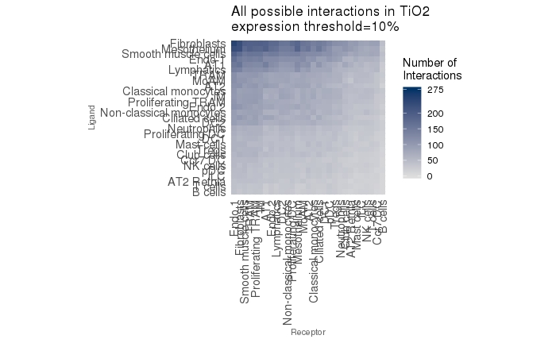

```r
heatmap_interactions("TiO2", all_ints_ti, limit = c(0, 275), breaks = c(0, 50, 100, 150, 200, 275))
```

```r
figure("results/tio2-all-interactions.pdf", function() {
  heatmap_interactions("TiO2", all_ints_ti, limit = c(0, 275), breaks = c(0, 50, 100, 150, 200, 275))
})
```

Asbestos sample

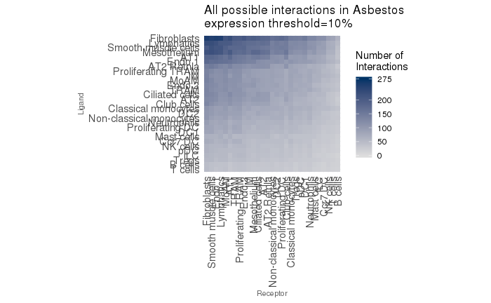

```r
heatmap_interactions("Asbestos", all_ints_as, threshold=0.1, limit = c(0, 275), breaks = c(0, 50, 100, 150, 200, 275))
```

```r
figure("results/asbestos-all-interactions.pdf", function() {
  heatmap_interactions("Asbestos", all_ints_as, threshold=0.1, limit = c(0, 275), breaks = c(0, 50, 100, 150, 200, 275))
})
```

Their difference

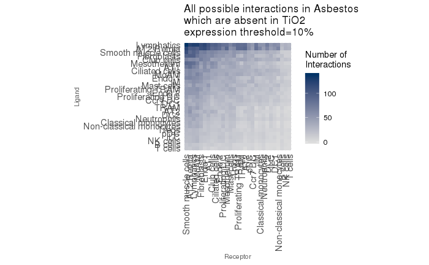

```r
heatmap_difference("TiO2", "Asbestos", all_ints_ti, all_ints_as, 0.1)
```

```r
figure("results/asbestos-specific-raw.pdf", function() {
  heatmap_difference("TiO2", "Asbestos", all_ints_ti, all_ints_as, 0.1)
})
```

## Differential expression analysis

We split each cluster into two by sample

```r
split_lung <- split_clusters(lung)
```

```r
interacting_genes <- c(pairs$ligand_symbol, pairs$receptor_symbol)
```

And compute the DE genes between samples within each cluster

```r
all_de_genes <- simpleCache("all_de_genes", {
    compute_split_de_genes(lung, split_lung, interacting_genes)
})
```

```
::Loading cache::   .cache/all_de_genes.RData
```

Next we select interactions from Asbestos sample where ligand or receptor gene is among the DE genes

```r
as_de_ints <- get_de_interactions(all_de_genes, all_ints_as, pairs)
```

And look at the difference in interactions at 10%, 5% and 1% expression thresholds

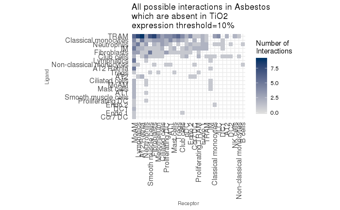

```r
heatmap_difference("TiO2", "Asbestos", all_ints_ti, as_de_ints, 0.1)
```

```r
figure("results/asbestos-specific-de.pdf", function() {
  heatmap_difference("TiO2", "Asbestos", all_ints_ti, as_de_ints, 0.1)
})
```

```r
figure("results/asbestos-specific-de-5pct.pdf", function() {
  heatmap_difference("TiO2", "Asbestos", all_ints_ti, as_de_ints, 0.05)
})
```

```r
figure("results/asbestos-specific-de-1pct.pdf", function() {
  heatmap_difference("TiO2", "Asbestos", all_ints_ti, as_de_ints, 0.01)
})
```

```r
as_de_ints_10 <- as_de_ints[as_de_ints$int_exp > 0.1, ]
as_de_ints_10 <- as_de_ints_10[!(as_de_ints_10$id %in% all_ints_ti$id[all_ints_ti$int_exp > 0.1]), ]
write.csv(cbind(
    as_de_ints_10,
    pairs[as_de_ints_10$lr_id, c(2, 4)]
), "results/asbestos-specific-de.csv")
```

```r
as_de_ints_05 <- as_de_ints[as_de_ints$int_exp > 0.1, ]
as_de_ints_05 <- as_de_ints_05[!(as_de_ints_05$id %in% all_ints_ti$id[all_ints_ti$int_exp > 0.1]), ]
write.csv(cbind(
    as_de_ints_05,
    pairs[as_de_ints_05$lr_id, c(2, 4)]
), "results/asbestos-specific-de-5pct.csv")
```

```r
as_de_ints_01 <- as_de_ints[as_de_ints$int_exp > 0.1, ]
as_de_ints_01 <- as_de_ints_01[!(as_de_ints_01$id %in% all_ints_ti$id[all_ints_ti$int_exp > 0.1]), ]
write.csv(cbind(
    as_de_ints_01,
    pairs[as_de_ints_01$lr_id, c(2, 4)]
), "results/asbestos-specific-de-1pct.csv")
```

## Focused analysis

We want to focus on cell types present in alveolar space. Also, we use more granular Macrophages annotations from separate Macrophages object

```r
lung_subset <- subset(lung, idents = c("TRAM", "MoAM", "AT2", "AT2_Retnla", "Fibroblasts", "IM"))
Idents(lung_subset, cells = WhichCells(Macrophages2, ident = "AM1")) <- "AM1"
Idents(lung_subset, cells = WhichCells(Macrophages2, ident = "AM2")) <- "AM2"
Idents(lung_subset, cells = WhichCells(Macrophages2, ident = "AM3")) <- "AM3"
Idents(lung_subset, cells = WhichCells(Macrophages2, ident = "IM1")) <- "IM1"
Idents(lung_subset, cells = WhichCells(Macrophages2, ident = "IM2")) <- "IM2"
lung_subset <- subset(lung_subset, idents = c("MoAM", "TRAM", "IM"), invert = TRUE)
```

Compute expression values for each cluster for each ligand and receptor gene

```r
raw_ligand_subset <- as.data.frame(as.matrix(get_gene_counts(lung_subset, pairs$ligand_symbol)))
raw_receptor_subset <- as.data.frame(as.matrix(get_gene_counts(lung_subset, pairs$receptor_symbol)))
ligand_expressed_subset <- apply(raw_ligand_subset, 1, expressed, cell_pops = Idents(lung_subset))
receptor_expressed_subset <- apply(raw_receptor_subset, 1, expressed, cell_pops = Idents(lung_subset))
```

Compute the table of interactions

```r
all_ints_subset <- simpleCache("subset_interactions", {
    get_all_interactions(ligand_expressed_subset, receptor_expressed_subset, pairs)
})
```

```
::Loading cache::   .cache/subset_interactions.RData
```

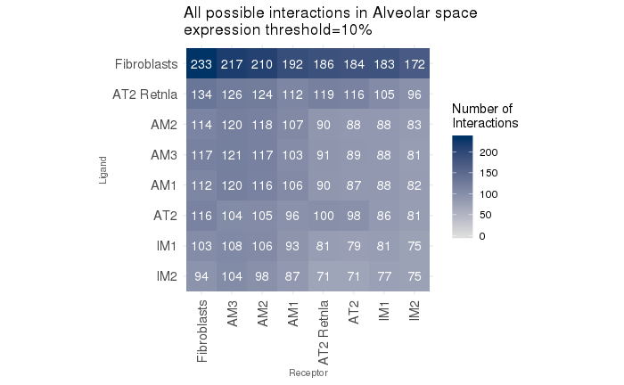

```r
heatmap_interactions("Alveolar space", all_ints_subset, show_labels = T, threshold = .1)
```

Save figures of interactions count for thresholds at 10%, 5% and 1%

```r
figure("results/combined-focused.pdf", function() {
  heatmap_interactions("Alveolar space", all_ints_subset, show_labels = T, threshold = .1)
})
```

```r
figure("results/combined-focused-5pct.pdf", function() {
  heatmap_interactions("Alveolar space", all_ints_subset, show_labels = T, threshold = .05)
})
```

```r
figure("results/combined-focused-1pct.pdf", function() {
  heatmap_interactions("Alveolar space", all_ints_subset, show_labels = T, threshold = .01)
})
```

And the corresponding tables of interactions themselves

```r
all_ints_subset_01 <- all_ints_subset[all_ints_subset$int_exp > .1, ]
write.csv(cbind(
    all_ints_subset_01,
    pairs[all_ints_subset_01$lr_id, c(2, 4)]
), "results/combined-focused.csv")
```

```r
all_ints_subset_005 <- all_ints_subset[all_ints_subset$int_exp > .05, ]
write.csv(cbind(
    all_ints_subset_005,
    pairs[all_ints_subset_005$lr_id, c(2, 4)]
), "results/combined-focused-5pct.csv")
```

```r
all_ints_subset_001 <- all_ints_subset[all_ints_subset$int_exp > .01, ]
write.csv(cbind(
    all_ints_subset_001,
    pairs[all_ints_subset_001$lr_id, c(2, 4)]
), "results/combined-focused-1pct.csv")
```